# Cerag Oguztuzun: Lab 07 for 431

## Question 2

To investigate whether the outcome variable `sbp_follow` can be modeled appropriately with a Normal distribution, a density plot and a Normal Q-Q plot are created. The density plot majorly looks like a bell-shaped curve of Normal distribution and we can see from the Normal Q-Q plot that the points majorly fit the diagonal line which suggests the distribution is normal. However, we can see some skew in the Normal Q-Q plot that resembles a uniform distribution, which shows itself in the density plot with a thick curve shape. To sum up, the outcome variable can be modeled with a Normal distribution well.

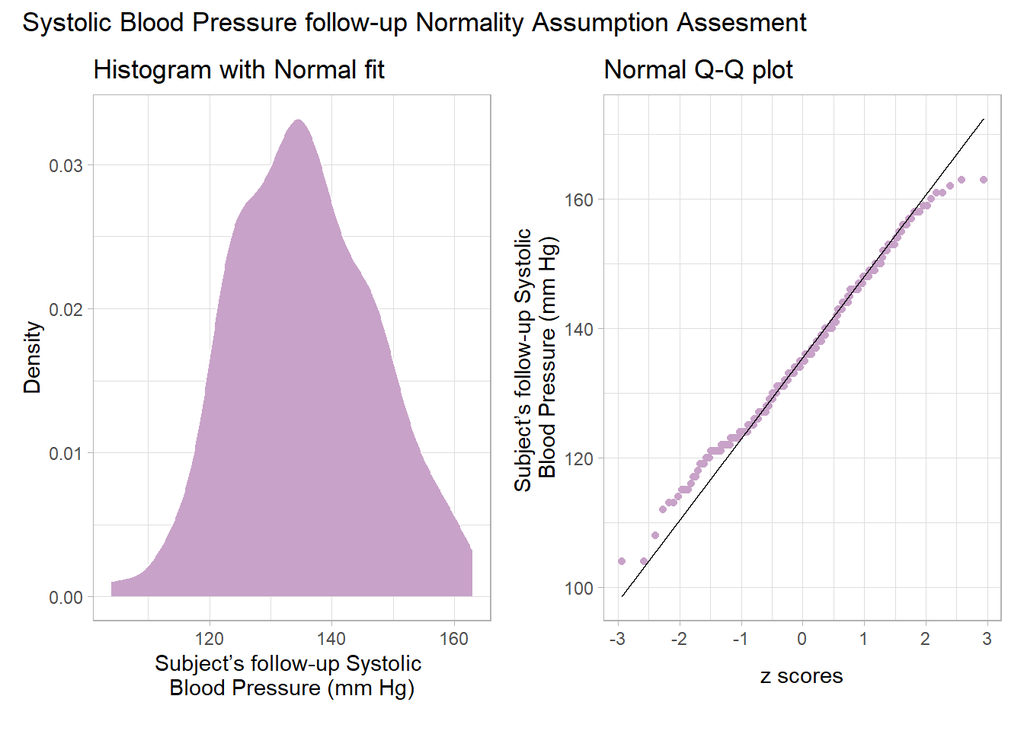

```r
p1 <- ggplot(lab07_trial, aes(x = sbp_follow)) +
    geom_density( fill = "#c8a2c8",
                   col = "white") +
    theme_light() +
    labs(title = "Histogram with Normal fit",
         x = "Subject’s follow-up Systolic \nBlood Pressure (mm Hg)", y = "Density")


p2 <- ggplot(lab07_trial, aes(sample = sbp_follow)) +
    geom_qq(col = "#c8a2c8") +
    geom_qq_line(col = "black") +
    theme_light() +

    labs(title = "Normal Q-Q plot",
         y = "Subject’s follow-up Systolic \nBlood Pressure (mm Hg)",
         x = 'z scores')


p1 + p2 + plot_layout(ncol =2, height = c(55, 1)) +
    plot_annotation(title = "Systolic Blood Pressure follow-up Normality Assumption Assesment")
```

## Question 3

The ANOVA assumptions are that the data is normally distributed, consisted of independent observations, has equal variance among groups. To assess these assumptions regarding the `lab07_trial` data, a violin plot is created where the dot represents the mean within each group. Assessing normality, we can see that the median is very close to the mean for each group, only group 2’s violin suggests the distribution for group 2 is a little right skewed as the mean is greater than the median slightly. Their variance is approximately the same regarding that the length of violins in the axis `subject’s follow-up systolic \nblood pressure (mm Hg)` are approximately equal. Also, the data from each group is independent. To sum up, this violin plot is in favor of using ANOVA to compare the SBP at follow-up means across the three treatment groups.

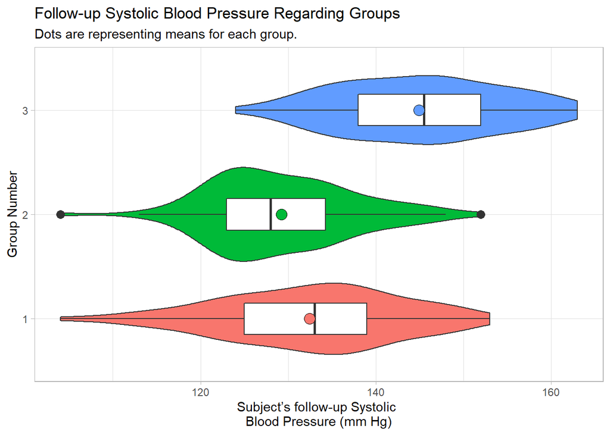

```r
ggplot(lab07_trial, aes(x = group, y = sbp_follow)) +
    theme_light() +
    geom_violin(aes(fill = group)) +
    geom_boxplot(width = 0.3, outlier.size = 3) +
    stat_summary(aes(fill = group), fun = mean,
                 geom="point", pch = 21, size = 4) +
    guides(fill = "none") +
    coord_flip() +
    labs(title = "Follow-up Systolic Blood Pressure Regarding Groups",
         subtitle = 'Dots are representing means for each group.',
         x = "Group Number", y = "Subject’s follow-up Systolic \nBlood Pressure (mm Hg)")
```

## Question 4

I will be using eta-squared which is an equivalent to R squared to assess this model. Using `η² = SS(Factor) / SS(Total)`, with SS(Factor) being SS(group) = 13779 and SS(Total) = SS(group) + SS(Residuals) = 13779 + 25518 = 39297. η² = 13779 / 39297 = 0.35064. This means `group` category accounts for 35% of variance in `sbp_follow`, which is a significant fraction, hence pairwise comparison will be done.

Also, Square root of Mean Square Residual value is the residual standard error which is √(85.91832) = 9.270.

```r
model4 <- lm(sbp_follow ~ group, data = lab07_trial, conf.level = 0.90)
anova(model4) %>% kable(digits = 5)
```

|  | Df | Sum Sq | Mean Sq | F value | Pr(>F) |
| --- | --- | --- | --- | --- | --- |
| group | 2 | 13778.61 | 6889.30333 | 80.18434 | 0 |
| Residuals | 297 | 25517.74 | 85.91832 | NA | NA |

TukeyHSD is used to assess pairwise confidence intervals and p values. We can see that p values for each group is very small which means the R squared values are statistically significant for each group. Additionally the confidence intervals do now include 0, which suggests the mean differences of each group of `sbp_follow` data of patients are statistically significant.

```r
TukeyHSD(aov(sbp_follow ~ group, data = lab07_trial, conf.level = 0.90))
```

```
  Tukey multiple comparisons of means
    95% family-wise confidence level

Fit: aov(formula = sbp_follow ~ group, data = lab07_trial, conf.level = 0.9)

$group
     diff       lwr        upr     p adj
2-1 -3.21 -6.297774 -0.1222256 0.0394605
3-1 12.50  9.412226 15.5877744 0.0000000
3-2 15.71 12.622226 18.7977744 0.0000000
```

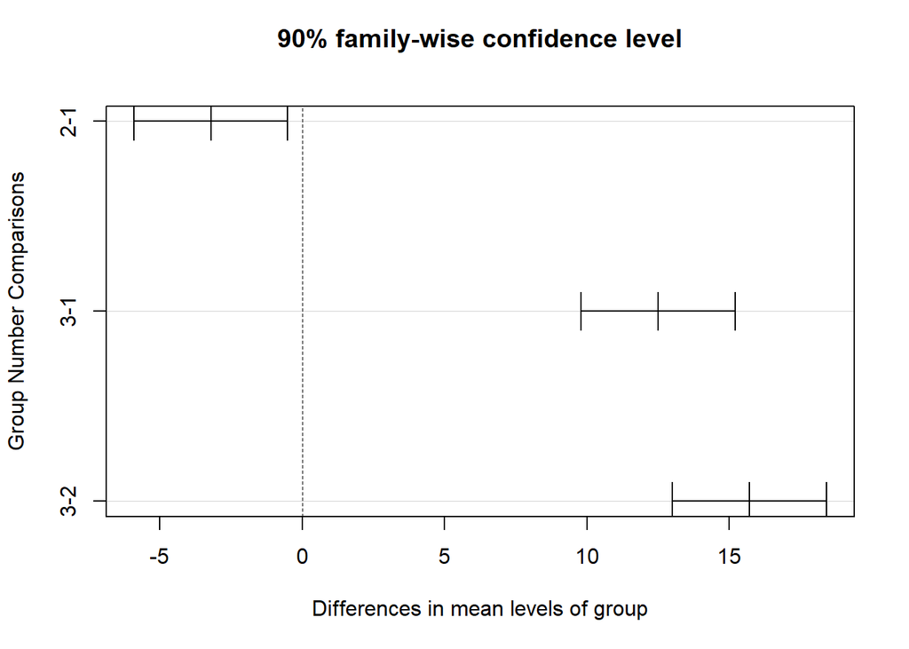

```r
plot(TukeyHSD(aov(sbp_follow ~ group, data = lab07_trial), conf.level = 0.90))
title(ylab="Group Number Comparisons")
```